# Risk Factor Analysis

## Outcome Variable

**Outcome Variable:** stunted

## Predictor Variables

**Intervention Variable:** birthwt

**Adjustment Set:**

- arm
- sex
- W_mage
- meducyrs
- feducyrs
- hhwealth_quart
- vagbrth
- W_nrooms
- brthmon
- W_parity
- impfloor
- impsan
- safeh20
- delta_W_mage
- delta_meducyrs
- delta_feducyrs
- delta_hhwealth_quart
- delta_vagbrth
- delta_W_nrooms
- delta_brthmon
- delta_W_parity
- delta_impfloor
- delta_impsan
- delta_safeh20

## Stratifying Variables

The analysis was stratified on these variable(s):

- agecat
- studyid
- country

## Data Summary

| agecat | studyid | country | birthwt | stunted | n_cell | n |
| --- | --- | --- | --- | --- | --- | --- |
| Birth | ki0047075b-MAL-ED | BANGLADESH | Normal or high birthweight | 0 | 186 | 257 |
| Birth | ki0047075b-MAL-ED | BANGLADESH | Normal or high birthweight | 1 | 16 | 257 |
| Birth | ki0047075b-MAL-ED | BANGLADESH | Low birth weight | 0 | 24 | 257 |
| Birth | ki0047075b-MAL-ED | BANGLADESH | Low birth weight | 1 | 31 | 257 |
| Birth | ki0047075b-MAL-ED | BRAZIL | Normal or high birthweight | 0 | 168 | 191 |
| Birth | ki0047075b-MAL-ED | BRAZIL | Normal or high birthweight | 1 | 15 | 191 |
| Birth | ki0047075b-MAL-ED | BRAZIL | Low birth weight | 0 | 2 | 191 |
| Birth | ki0047075b-MAL-ED | BRAZIL | Low birth weight | 1 | 6 | 191 |
| Birth | ki0047075b-MAL-ED | INDIA | Normal or high birthweight | 0 | 154 | 206 |
| Birth | ki0047075b-MAL-ED | INDIA | Normal or high birthweight | 1 | 18 | 206 |
| Birth | ki0047075b-MAL-ED | INDIA | Low birth weight | 0 | 19 | 206 |
| Birth | ki0047075b-MAL-ED | INDIA | Low birth weight | 1 | 15 | 206 |
| Birth | ki0047075b-MAL-ED | NEPAL | Normal or high birthweight | 0 | 148 | 173 |
| Birth | ki0047075b-MAL-ED | NEPAL | Normal or high birthweight | 1 | 7 | 173 |
| Birth | ki0047075b-MAL-ED | NEPAL | Low birth weight | 0 | 7 | 173 |
| Birth | ki0047075b-MAL-ED | NEPAL | Low birth weight | 1 | 11 | 173 |
| Birth | ki0047075b-MAL-ED | PERU | Normal or high birthweight | 0 | 251 | 287 |
| Birth | ki0047075b-MAL-ED | PERU | Normal or high birthweight | 1 | 18 | 287 |
| Birth | ki0047075b-MAL-ED | PERU | Low birth weight | 0 | 2 | 287 |
| Birth | ki0047075b-MAL-ED | PERU | Low birth weight | 1 | 16 | 287 |
| Birth | ki0047075b-MAL-ED | SOUTH AFRICA | Normal or high birthweight | 0 | 227 | 262 |
| Birth | ki0047075b-MAL-ED | SOUTH AFRICA | Normal or high birthweight | 1 | 17 | 262 |
| Birth | ki0047075b-MAL-ED | SOUTH AFRICA | Low birth weight | 0 | 7 | 262 |
| Birth | ki0047075b-MAL-ED | SOUTH AFRICA | Low birth weight | 1 | 11 | 262 |
| Birth | ki0047075b-MAL-ED | TANZANIA, UNITED REPUBLIC OF | Normal or high birthweight | 0 | 104 | 123 |
| Birth | ki0047075b-MAL-ED | TANZANIA, UNITED REPUBLIC OF | Normal or high birthweight | 1 | 12 | 123 |
| Birth | ki0047075b-MAL-ED | TANZANIA, UNITED REPUBLIC OF | Low birth weight | 0 | 1 | 123 |
| Birth | ki0047075b-MAL-ED | TANZANIA, UNITED REPUBLIC OF | Low birth weight | 1 | 6 | 123 |
| Birth | ki1000108-CMC-V-BCS-2002 | INDIA | Normal or high birthweight | 0 | 70 | 90 |
| Birth | ki1000108-CMC-V-BCS-2002 | INDIA | Normal or high birthweight | 1 | 10 | 90 |

[output cut: 286 more lines]

The following strata were considered:

- agecat: 24 months, studyid: ki0047075b-MAL-ED, country: BANGLADESH
- agecat: 24 months, studyid: ki0047075b-MAL-ED, country: BRAZIL
- agecat: 24 months, studyid: ki0047075b-MAL-ED, country: INDIA
- agecat: 24 months, studyid: ki0047075b-MAL-ED, country: NEPAL
- agecat: 24 months, studyid: ki0047075b-MAL-ED, country: PERU
- agecat: 24 months, studyid: ki0047075b-MAL-ED, country: SOUTH AFRICA
- agecat: 24 months, studyid: ki0047075b-MAL-ED, country: TANZANIA, UNITED REPUBLIC OF
- agecat: 24 months, studyid: ki1000108-CMC-V-BCS-2002, country: INDIA
- agecat: 24 months, studyid: ki1000108-IRC, country: INDIA
- agecat: 24 months, studyid: ki1017093-NIH-Birth, country: BANGLADESH
- agecat: 24 months, studyid: ki1017093b-PROVIDE, country: BANGLADESH
- agecat: 24 months, studyid: ki1017093c-NIH-Crypto, country: BANGLADESH
- agecat: 24 months, studyid: ki1066203-TanzaniaChild2, country: TANZANIA, UNITED REPUBLIC OF
- agecat: 24 months, studyid: ki1101329-Keneba, country: GAMBIA
- agecat: 24 months, studyid: ki1114097-CMIN, country: BANGLADESH
- agecat: 24 months, studyid: ki1114097-CMIN, country: PERU
- agecat: 24 months, studyid: ki1114097-CONTENT, country: PERU
- agecat: 24 months, studyid: ki1119695-PROBIT, country: BELARUS
- agecat: 24 months, studyid: ki1126311-ZVITAMBO, country: ZIMBABWE
- agecat: 24 months, studyid: ki1135781-COHORTS, country: GUATEMALA
- agecat: 24 months, studyid: ki1135781-COHORTS, country: INDIA
- agecat: 24 months, studyid: ki1135781-COHORTS, country: PHILIPPINES
- agecat: 24 months, studyid: kiGH5241-JiVitA-3, country: BANGLADESH
- agecat: 24 months, studyid: kiGH5241-JiVitA-4, country: BANGLADESH
- agecat: 6 months, studyid: ki0047075b-MAL-ED, country: BANGLADESH
- agecat: 6 months, studyid: ki0047075b-MAL-ED, country: BRAZIL
- agecat: 6 months, studyid: ki0047075b-MAL-ED, country: INDIA
- agecat: 6 months, studyid: ki0047075b-MAL-ED, country: NEPAL
- agecat: 6 months, studyid: ki0047075b-MAL-ED, country: PERU
- agecat: 6 months, studyid: ki0047075b-MAL-ED, country: SOUTH AFRICA
- agecat: 6 months, studyid: ki0047075b-MAL-ED, country: TANZANIA, UNITED REPUBLIC OF
- agecat: 6 months, studyid: ki1000108-CMC-V-BCS-2002, country: INDIA
- agecat: 6 months, studyid: ki1000108-IRC, country: INDIA
- agecat: 6 months, studyid: ki1000109-EE, country: PAKISTAN
- agecat: 6 months, studyid: ki1000109-ResPak, country: PAKISTAN
- agecat: 6 months, studyid: ki1000304b-SAS-CompFeed, country: INDIA
- agecat: 6 months, studyid: ki1017093-NIH-Birth, country: BANGLADESH
- agecat: 6 months, studyid: ki1017093b-PROVIDE, country: BANGLADESH
- agecat: 6 months, studyid: ki1017093c-NIH-Crypto, country: BANGLADESH
- agecat: 6 months, studyid: ki1066203-TanzaniaChild2, country: TANZANIA, UNITED REPUBLIC OF
- agecat: 6 months, studyid: ki1101329-Keneba, country: GAMBIA
- agecat: 6 months, studyid: ki1114097-CMIN, country: BANGLADESH
- agecat: 6 months, studyid: ki1114097-CMIN, country: BRAZIL
- agecat: 6 months, studyid: ki1114097-CMIN, country: GUINEA-BISSAU
- agecat: 6 months, studyid: ki1114097-CMIN, country: PERU
- agecat: 6 months, studyid: ki1114097-CONTENT, country: PERU
- agecat: 6 months, studyid: ki1119695-PROBIT, country: BELARUS
- agecat: 6 months, studyid: ki1126311-ZVITAMBO, country: ZIMBABWE
- agecat: 6 months, studyid: ki1135781-COHORTS, country: GUATEMALA
- agecat: 6 months, studyid: ki1135781-COHORTS, country: INDIA
- agecat: 6 months, studyid: ki1135781-COHORTS, country: PHILIPPINES
- agecat: 6 months, studyid: kiGH5241-JiVitA-3, country: BANGLADESH
- agecat: 6 months, studyid: kiGH5241-JiVitA-4, country: BANGLADESH
- agecat: Birth, studyid: ki0047075b-MAL-ED, country: BANGLADESH
- agecat: Birth, studyid: ki0047075b-MAL-ED, country: BRAZIL
- agecat: Birth, studyid: ki0047075b-MAL-ED, country: INDIA
- agecat: Birth, studyid: ki0047075b-MAL-ED, country: NEPAL
- agecat: Birth, studyid: ki0047075b-MAL-ED, country: PERU
- agecat: Birth, studyid: ki0047075b-MAL-ED, country: SOUTH AFRICA
- agecat: Birth, studyid: ki0047075b-MAL-ED, country: TANZANIA, UNITED REPUBLIC OF
- agecat: Birth, studyid: ki1000108-CMC-V-BCS-2002, country: INDIA
- agecat: Birth, studyid: ki1000108-IRC, country: INDIA
- agecat: Birth, studyid: ki1000109-EE, country: PAKISTAN
- agecat: Birth, studyid: ki1000109-ResPak, country: PAKISTAN
- agecat: Birth, studyid: ki1000304b-SAS-CompFeed, country: INDIA
- agecat: Birth, studyid: ki1017093-NIH-Birth, country: BANGLADESH
- agecat: Birth, studyid: ki1017093c-NIH-Crypto, country: BANGLADESH
- agecat: Birth, studyid: ki1101329-Keneba, country: GAMBIA
- agecat: Birth, studyid: ki1114097-CMIN, country: BANGLADESH
- agecat: Birth, studyid: ki1114097-CMIN, country: BRAZIL
- agecat: Birth, studyid: ki1114097-CMIN, country: PERU
- agecat: Birth, studyid: ki1114097-CONTENT, country: PERU
- agecat: Birth, studyid: ki1119695-PROBIT, country: BELARUS
- agecat: Birth, studyid: ki1126311-ZVITAMBO, country: ZIMBABWE
- agecat: Birth, studyid: ki1135781-COHORTS, country: GUATEMALA
- agecat: Birth, studyid: ki1135781-COHORTS, country: INDIA
- agecat: Birth, studyid: ki1135781-COHORTS, country: PHILIPPINES
- agecat: Birth, studyid: kiGH5241-JiVitA-3, country: BANGLADESH
- agecat: Birth, studyid: kiGH5241-JiVitA-4, country: BANGLADESH

### Dropped Strata

Some strata were dropped due to rare outcomes:

- agecat: Birth, studyid: ki0047075b-MAL-ED, country: BRAZIL
- agecat: Birth, studyid: ki0047075b-MAL-ED, country: PERU
- agecat: Birth, studyid: ki0047075b-MAL-ED, country: TANZANIA, UNITED REPUBLIC OF
- agecat: Birth, studyid: ki1000108-CMC-V-BCS-2002, country: INDIA
- agecat: Birth, studyid: ki1000109-EE, country: PAKISTAN
- agecat: Birth, studyid: ki1000109-ResPak, country: PAKISTAN
- agecat: Birth, studyid: ki1017093-NIH-Birth, country: BANGLADESH
- agecat: Birth, studyid: ki1017093c-NIH-Crypto, country: BANGLADESH
- agecat: Birth, studyid: ki1114097-CMIN, country: BANGLADESH
- agecat: Birth, studyid: ki1114097-CMIN, country: BRAZIL
- agecat: Birth, studyid: ki1114097-CMIN, country: PERU
- agecat: Birth, studyid: ki1114097-CONTENT, country: PERU
- agecat: Birth, studyid: ki1119695-PROBIT, country: BELARUS
- agecat: 6 months, studyid: ki0047075b-MAL-ED, country: BRAZIL
- agecat: 6 months, studyid: ki0047075b-MAL-ED, country: TANZANIA, UNITED REPUBLIC OF
- agecat: 6 months, studyid: ki1000109-ResPak, country: PAKISTAN
- agecat: 6 months, studyid: ki1114097-CMIN, country: BANGLADESH
- agecat: 6 months, studyid: ki1114097-CMIN, country: BRAZIL
- agecat: 6 months, studyid: ki1114097-CMIN, country: GUINEA-BISSAU
- agecat: 6 months, studyid: ki1114097-CMIN, country: PERU
- agecat: 6 months, studyid: ki1114097-CONTENT, country: PERU
- agecat: 6 months, studyid: ki1119695-PROBIT, country: BELARUS
- agecat: 24 months, studyid: ki0047075b-MAL-ED, country: BRAZIL
- agecat: 24 months, studyid: ki0047075b-MAL-ED, country: PERU
- agecat: 24 months, studyid: ki0047075b-MAL-ED, country: SOUTH AFRICA
- agecat: 24 months, studyid: ki0047075b-MAL-ED, country: TANZANIA, UNITED REPUBLIC OF
- agecat: 24 months, studyid: ki1066203-TanzaniaChild2, country: TANZANIA, UNITED REPUBLIC OF
- agecat: 24 months, studyid: ki1114097-CMIN, country: BANGLADESH
- agecat: 24 months, studyid: ki1114097-CMIN, country: PERU
- agecat: 24 months, studyid: ki1114097-CONTENT, country: PERU
- agecat: 24 months, studyid: ki1119695-PROBIT, country: BELARUS
- agecat: 24 months, studyid: ki1135781-COHORTS, country: GUATEMALA

## Methods Detail

We’re interested in the causal parameters $E[Y_a]$ for all values of $a \in \mathcal{A}$. These parameters represent the mean outcome if, possibly contrary to fact, we intervened to set all units to have $A=a$. Under the randomization and positivity assumptions, these are identified by the statistical parameters $\psi_a=E_W[E_{Y|A,W}(Y|A=a,W)]$. In addition, we’re interested in the mean of $Y$, $E[Y]$ under no intervention (the observed mean). We will estimate these parameters by using SuperLearner to fit the relevant likelihood factors – $E_{Y|A,W}(Y|A=a,W)$ and $p(A=a|W)$, and then updating our likelihood fit using a joint TMLE.

For unadjusted analyses ($W=\{\}$), initial likelihoods were estimated using Lrnr_glm to estimate the simple $E(Y|A)$ and Lrnr_mean to estimate $p(A)$. For adjusted analyses, a small library containing Lrnr_glmnet, Lrnr_xgboost, and Lrnr_mean was used.

Having estimated these parameters, we will then use the delta method to estimate relative risks and attributable risks relative to a prespecified baseline level of $A$.

# Results Detail

## Results Plots

[figure not shown]

[figure not shown]

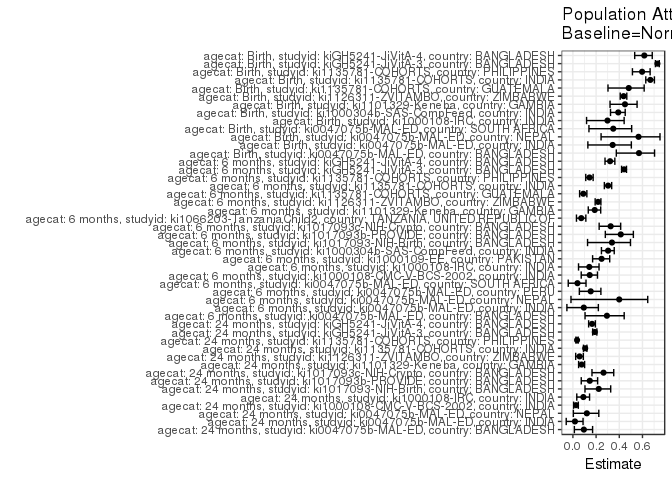

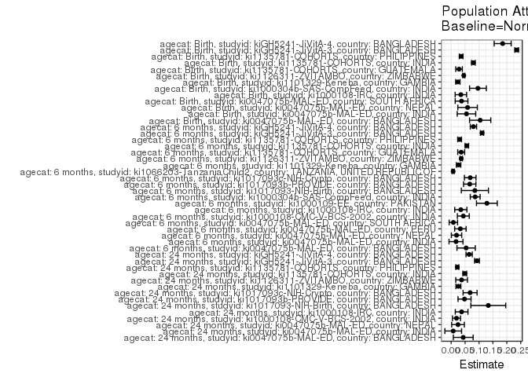

## Results Table

### Parameter: TSM

| agecat | studyid | country | intervention_level | baseline_level | estimate | ci_lower | ci_upper |
| --- | --- | --- | --- | --- | --- | --- | --- |
| Birth | ki0047075b-MAL-ED | BANGLADESH | Normal or high birthweight | NA | 0.0786853 | 0.0414076 | 0.1159630 |
| Birth | ki0047075b-MAL-ED | BANGLADESH | Low birth weight | NA | 0.5700248 | 0.4377552 | 0.7022944 |
| Birth | ki0047075b-MAL-ED | INDIA | Normal or high birthweight | NA | 0.1052931 | 0.0594649 | 0.1511213 |
| Birth | ki0047075b-MAL-ED | INDIA | Low birth weight | NA | 0.4349405 | 0.2680752 | 0.6018059 |
| Birth | ki0047075b-MAL-ED | NEPAL | Normal or high birthweight | NA | 0.0451613 | 0.0123752 | 0.0779474 |
| Birth | ki0047075b-MAL-ED | NEPAL | Low birth weight | NA | 0.6111111 | 0.3852489 | 0.8369733 |
| Birth | ki0047075b-MAL-ED | SOUTH AFRICA | Normal or high birthweight | NA | 0.0696721 | 0.0376662 | 0.1016781 |
| Birth | ki0047075b-MAL-ED | SOUTH AFRICA | Low birth weight | NA | 0.6111111 | 0.3854716 | 0.8367506 |
| Birth | ki1000108-IRC | INDIA | Normal or high birthweight | NA | 0.0818009 | 0.0518474 | 0.1117544 |
| Birth | ki1000108-IRC | INDIA | Low birth weight | NA | 0.2800514 | 0.1730756 | 0.3870271 |
| Birth | ki1000304b-SAS-CompFeed | INDIA | Normal or high birthweight | NA | 0.1498109 | 0.0883827 | 0.2112392 |
| Birth | ki1000304b-SAS-CompFeed | INDIA | Low birth weight | NA | 0.5977770 | 0.4479665 | 0.7475875 |
| Birth | ki1101329-Keneba | GAMBIA | Normal or high birthweight | NA | 0.0293195 | 0.0204996 | 0.0381394 |
| Birth | ki1101329-Keneba | GAMBIA | Low birth weight | NA | 0.2686149 | 0.2105311 | 0.3266986 |
| Birth | ki1126311-ZVITAMBO | ZIMBABWE | Normal or high birthweight | NA | 0.0582817 | 0.0540842 | 0.0624792 |
| Birth | ki1126311-ZVITAMBO | ZIMBABWE | Low birth weight | NA | 0.3887355 | 0.3677559 | 0.4097152 |
| Birth | ki1135781-COHORTS | GUATEMALA | Normal or high birthweight | NA | 0.0304215 | 0.0177717 | 0.0430712 |
| Birth | ki1135781-COHORTS | GUATEMALA | Low birth weight | NA | 0.3591898 | 0.2624610 | 0.4559185 |
| Birth | ki1135781-COHORTS | INDIA | Normal or high birthweight | NA | 0.0396402 | 0.0343877 | 0.0448927 |
| Birth | ki1135781-COHORTS | INDIA | Low birth weight | NA | 0.4256164 | 0.4008797 | 0.4503531 |
| Birth | ki1135781-COHORTS | PHILIPPINES | Normal or high birthweight | NA | 0.0241605 | 0.0183956 | 0.0299255 |
| Birth | ki1135781-COHORTS | PHILIPPINES | Low birth weight | NA | 0.3751240 | 0.3289497 | 0.4212982 |
| Birth | kiGH5241-JiVitA-3 | BANGLADESH | Normal or high birthweight | NA | 0.0876165 | 0.0814863 | 0.0937466 |
| Birth | kiGH5241-JiVitA-3 | BANGLADESH | Low birth weight | NA | 0.6427371 | 0.6315481 | 0.6539262 |
| Birth | kiGH5241-JiVitA-4 | BANGLADESH | Normal or high birthweight | NA | 0.1153910 | 0.0883154 | 0.1424665 |
| Birth | kiGH5241-JiVitA-4 | BANGLADESH | Low birth weight | NA | 0.6853757 | 0.6249849 | 0.7457666 |
| 6 months | ki0047075b-MAL-ED | BANGLADESH | Normal or high birthweight | NA | 0.1293054 | 0.0812353 | 0.1773754 |
| 6 months | ki0047075b-MAL-ED | BANGLADESH | Low birth weight | NA | 0.4227333 | 0.2864585 | 0.5590082 |
| 6 months | ki0047075b-MAL-ED | INDIA | Normal or high birthweight | NA | 0.1661736 | 0.1136001 | 0.2187470 |
| 6 months | ki0047075b-MAL-ED | INDIA | Low birth weight | NA | 0.2749100 | 0.1279591 | 0.4218610 |

[output cut: 64 more lines]

### Parameter: E(Y)

| agecat | studyid | country | intervention_level | baseline_level | estimate | ci_lower | ci_upper |
| --- | --- | --- | --- | --- | --- | --- | --- |
| Birth | ki0047075b-MAL-ED | BANGLADESH | NA | NA | 0.1828794 | 0.1355257 | 0.2302330 |
| Birth | ki0047075b-MAL-ED | INDIA | NA | NA | 0.1601942 | 0.1099849 | 0.2104035 |
| Birth | ki0047075b-MAL-ED | NEPAL | NA | NA | 0.1040462 | 0.0584174 | 0.1496751 |
| Birth | ki0047075b-MAL-ED | SOUTH AFRICA | NA | NA | 0.1068702 | 0.0693890 | 0.1443514 |
| Birth | ki1000108-IRC | INDIA | NA | NA | 0.1165803 | 0.0845240 | 0.1486366 |
| Birth | ki1000304b-SAS-CompFeed | INDIA | NA | NA | 0.2459893 | 0.1594019 | 0.3325767 |
| Birth | ki1101329-Keneba | GAMBIA | NA | NA | 0.0532122 | 0.0420018 | 0.0644226 |
| Birth | ki1126311-ZVITAMBO | ZIMBABWE | NA | NA | 0.1035430 | 0.0984652 | 0.1086208 |
| Birth | ki1135781-COHORTS | GUATEMALA | NA | NA | 0.0586735 | 0.0422124 | 0.0751345 |
| Birth | ki1135781-COHORTS | INDIA | NA | NA | 0.1193130 | 0.1115144 | 0.1271117 |
| Birth | ki1135781-COHORTS | PHILIPPINES | NA | NA | 0.0599201 | 0.0514314 | 0.0684088 |
| Birth | kiGH5241-JiVitA-3 | BANGLADESH | NA | NA | 0.3231185 | 0.3154668 | 0.3307702 |
| Birth | kiGH5241-JiVitA-4 | BANGLADESH | NA | NA | 0.3004866 | 0.2649179 | 0.3360553 |
| 6 months | ki0047075b-MAL-ED | BANGLADESH | NA | NA | 0.1829787 | 0.1334386 | 0.2325189 |
| 6 months | ki0047075b-MAL-ED | INDIA | NA | NA | 0.1834061 | 0.1331729 | 0.2336393 |
| 6 months | ki0047075b-MAL-ED | NEPAL | NA | NA | 0.0480349 | 0.0202781 | 0.0757918 |
| 6 months | ki0047075b-MAL-ED | PERU | NA | NA | 0.2148148 | 0.1657364 | 0.2638932 |
| 6 months | ki0047075b-MAL-ED | SOUTH AFRICA | NA | NA | 0.1968504 | 0.1478551 | 0.2458457 |
| 6 months | ki1000108-CMC-V-BCS-2002 | INDIA | NA | NA | 0.3008130 | 0.2539566 | 0.3476694 |
| 6 months | ki1000108-IRC | INDIA | NA | NA | 0.2444444 | 0.2025380 | 0.2863509 |
| 6 months | ki1000109-EE | PAKISTAN | NA | NA | 0.5188172 | 0.4679751 | 0.5696593 |
| 6 months | ki1000304b-SAS-CompFeed | INDIA | NA | NA | 0.2843137 | 0.2660295 | 0.3025980 |
| 6 months | ki1017093-NIH-Birth | BANGLADESH | NA | NA | 0.2528090 | 0.1887805 | 0.3168375 |
| 6 months | ki1017093b-PROVIDE | BANGLADESH | NA | NA | 0.1612350 | 0.1313580 | 0.1911120 |
| 6 months | ki1017093c-NIH-Crypto | BANGLADESH | NA | NA | 0.2097902 | 0.1799252 | 0.2396552 |
| 6 months | ki1066203-TanzaniaChild2 | TANZANIA, UNITED REPUBLIC OF | NA | NA | 0.0964694 | 0.0835627 | 0.1093762 |
| 6 months | ki1101329-Keneba | GAMBIA | NA | NA | 0.1414493 | 0.1249994 | 0.1578992 |
| 6 months | ki1126311-ZVITAMBO | ZIMBABWE | NA | NA | 0.1660012 | 0.1579791 | 0.1740234 |
| 6 months | ki1135781-COHORTS | GUATEMALA | NA | NA | 0.4007782 | 0.3661645 | 0.4353920 |
| 6 months | ki1135781-COHORTS | INDIA | NA | NA | 0.1852739 | 0.1756495 | 0.1948983 |
| 6 months | ki1135781-COHORTS | PHILIPPINES | NA | NA | 0.2108027 | 0.1953170 | 0.2262884 |
| 6 months | kiGH5241-JiVitA-3 | BANGLADESH | NA | NA | 0.2513890 | 0.2432761 | 0.2595019 |
| 6 months | kiGH5241-JiVitA-4 | BANGLADESH | NA | NA | 0.2495047 | 0.2333837 | 0.2656257 |
| 24 months | ki0047075b-MAL-ED | BANGLADESH | NA | NA | 0.4567308 | 0.3888728 | 0.5245887 |
| 24 months | ki0047075b-MAL-ED | INDIA | NA | NA | 0.4136364 | 0.3484106 | 0.4788621 |
| 24 months | ki0047075b-MAL-ED | NEPAL | NA | NA | 0.2036199 | 0.1504082 | 0.2568316 |
| 24 months | ki1000108-CMC-V-BCS-2002 | INDIA | NA | NA | 0.7150538 | 0.6691221 | 0.7609854 |
| 24 months | ki1000108-IRC | INDIA | NA | NA | 0.4152334 | 0.3673018 | 0.4631651 |
| 24 months | ki1017093-NIH-Birth | BANGLADESH | NA | NA | 0.5985401 | 0.5161555 | 0.6809248 |
| 24 months | ki1017093b-PROVIDE | BANGLADESH | NA | NA | 0.3292894 | 0.2909105 | 0.3676684 |
| 24 months | ki1017093c-NIH-Crypto | BANGLADESH | NA | NA | 0.2568093 | 0.2190047 | 0.2946140 |
| 24 months | ki1101329-Keneba | GAMBIA | NA | NA | 0.3426184 | 0.3180636 | 0.3671732 |
| 24 months | ki1126311-ZVITAMBO | ZIMBABWE | NA | NA | 0.6505495 | 0.6066910 | 0.6944079 |
| 24 months | ki1135781-COHORTS | INDIA | NA | NA | 0.4603991 | 0.4463860 | 0.4744122 |
| 24 months | ki1135781-COHORTS | PHILIPPINES | NA | NA | 0.6151288 | 0.5956828 | 0.6345749 |
| 24 months | kiGH5241-JiVitA-3 | BANGLADESH | NA | NA | 0.4908233 | 0.4776585 | 0.5039881 |
| 24 months | kiGH5241-JiVitA-4 | BANGLADESH | NA | NA | 0.3905665 | 0.3718944 | 0.4092386 |

### Parameter: RR

| agecat | studyid | country | intervention_level | baseline_level | estimate | ci_lower | ci_upper |
| --- | --- | --- | --- | --- | --- | --- | --- |
| Birth | ki0047075b-MAL-ED | BANGLADESH | Normal or high birthweight | Normal or high birthweight | 1.000000 | 1.0000000 | 1.000000 |
| Birth | ki0047075b-MAL-ED | BANGLADESH | Low birth weight | Normal or high birthweight | 7.244365 | 4.2757197 | 12.274152 |
| Birth | ki0047075b-MAL-ED | INDIA | Normal or high birthweight | Normal or high birthweight | 1.000000 | 1.0000000 | 1.000000 |
| Birth | ki0047075b-MAL-ED | INDIA | Low birth weight | Normal or high birthweight | 4.130761 | 2.3132536 | 7.376272 |
| Birth | ki0047075b-MAL-ED | NEPAL | Normal or high birthweight | Normal or high birthweight | 1.000000 | 1.0000000 | 1.000000 |
| Birth | ki0047075b-MAL-ED | NEPAL | Low birth weight | Normal or high birthweight | 13.531746 | 5.9918281 | 30.559645 |
| Birth | ki0047075b-MAL-ED | SOUTH AFRICA | Normal or high birthweight | Normal or high birthweight | 1.000000 | 1.0000000 | 1.000000 |
| Birth | ki0047075b-MAL-ED | SOUTH AFRICA | Low birth weight | Normal or high birthweight | 8.771242 | 4.8651927 | 15.813286 |
| Birth | ki1000108-IRC | INDIA | Normal or high birthweight | Normal or high birthweight | 1.000000 | 1.0000000 | 1.000000 |
| Birth | ki1000108-IRC | INDIA | Low birth weight | Normal or high birthweight | 3.423573 | 2.0218205 | 5.797179 |
| Birth | ki1000304b-SAS-CompFeed | INDIA | Normal or high birthweight | Normal or high birthweight | 1.000000 | 1.0000000 | 1.000000 |
| Birth | ki1000304b-SAS-CompFeed | INDIA | Low birth weight | Normal or high birthweight | 3.990210 | 3.2374240 | 4.918037 |
| Birth | ki1101329-Keneba | GAMBIA | Normal or high birthweight | Normal or high birthweight | 1.000000 | 1.0000000 | 1.000000 |
| Birth | ki1101329-Keneba | GAMBIA | Low birth weight | Normal or high birthweight | 9.161647 | 6.3261792 | 13.268004 |
| Birth | ki1126311-ZVITAMBO | ZIMBABWE | Normal or high birthweight | Normal or high birthweight | 1.000000 | 1.0000000 | 1.000000 |
| Birth | ki1126311-ZVITAMBO | ZIMBABWE | Low birth weight | Normal or high birthweight | 6.669947 | 6.0962232 | 7.297665 |
| Birth | ki1135781-COHORTS | GUATEMALA | Normal or high birthweight | Normal or high birthweight | 1.000000 | 1.0000000 | 1.000000 |
| Birth | ki1135781-COHORTS | GUATEMALA | Low birth weight | Normal or high birthweight | 11.807119 | 7.2086182 | 19.339084 |
| Birth | ki1135781-COHORTS | INDIA | Normal or high birthweight | Normal or high birthweight | 1.000000 | 1.0000000 | 1.000000 |
| Birth | ki1135781-COHORTS | INDIA | Low birth weight | Normal or high birthweight | 10.736990 | 9.2919301 | 12.406783 |
| Birth | ki1135781-COHORTS | PHILIPPINES | Normal or high birthweight | Normal or high birthweight | 1.000000 | 1.0000000 | 1.000000 |
| Birth | ki1135781-COHORTS | PHILIPPINES | Low birth weight | Normal or high birthweight | 15.526309 | 11.8743058 | 20.301505 |
| Birth | kiGH5241-JiVitA-3 | BANGLADESH | Normal or high birthweight | Normal or high birthweight | 1.000000 | 1.0000000 | 1.000000 |
| Birth | kiGH5241-JiVitA-3 | BANGLADESH | Low birth weight | Normal or high birthweight | 7.335804 | 6.8352956 | 7.872961 |
| Birth | kiGH5241-JiVitA-4 | BANGLADESH | Normal or high birthweight | Normal or high birthweight | 1.000000 | 1.0000000 | 1.000000 |
| Birth | kiGH5241-JiVitA-4 | BANGLADESH | Low birth weight | Normal or high birthweight | 5.939596 | 4.6136729 | 7.646576 |
| 6 months | ki0047075b-MAL-ED | BANGLADESH | Normal or high birthweight | Normal or high birthweight | 1.000000 | 1.0000000 | 1.000000 |
| 6 months | ki0047075b-MAL-ED | BANGLADESH | Low birth weight | Normal or high birthweight | 3.269263 | 1.9968854 | 5.352376 |
| 6 months | ki0047075b-MAL-ED | INDIA | Normal or high birthweight | Normal or high birthweight | 1.000000 | 1.0000000 | 1.000000 |
| 6 months | ki0047075b-MAL-ED | INDIA | Low birth weight | Normal or high birthweight | 1.654355 | 0.8888690 | 3.079070 |

[output cut: 64 more lines]

### Parameter: PAR

| agecat | studyid | country | intervention_level | baseline_level | estimate | ci_lower | ci_upper |
| --- | --- | --- | --- | --- | --- | --- | --- |
| Birth | ki0047075b-MAL-ED | BANGLADESH | Normal or high birthweight | NA | 0.1041941 | 0.0660570 | 0.1423313 |
| Birth | ki0047075b-MAL-ED | INDIA | Normal or high birthweight | NA | 0.0549011 | 0.0216522 | 0.0881500 |
| Birth | ki0047075b-MAL-ED | NEPAL | Normal or high birthweight | NA | 0.0588850 | 0.0238029 | 0.0939670 |
| Birth | ki0047075b-MAL-ED | SOUTH AFRICA | Normal or high birthweight | NA | 0.0371981 | 0.0143680 | 0.0600282 |
| Birth | ki1000108-IRC | INDIA | Normal or high birthweight | NA | 0.0347794 | 0.0141654 | 0.0553934 |
| Birth | ki1000304b-SAS-CompFeed | INDIA | Normal or high birthweight | NA | 0.0961784 | 0.0660839 | 0.1262728 |
| Birth | ki1101329-Keneba | GAMBIA | Normal or high birthweight | NA | 0.0238927 | 0.0160279 | 0.0317575 |
| Birth | ki1126311-ZVITAMBO | ZIMBABWE | Normal or high birthweight | NA | 0.0452614 | 0.0416670 | 0.0488557 |
| Birth | ki1135781-COHORTS | GUATEMALA | Normal or high birthweight | NA | 0.0282520 | 0.0164706 | 0.0400335 |
| Birth | ki1135781-COHORTS | INDIA | Normal or high birthweight | NA | 0.0796728 | 0.0730127 | 0.0863330 |
| Birth | ki1135781-COHORTS | PHILIPPINES | Normal or high birthweight | NA | 0.0357596 | 0.0290545 | 0.0424646 |
| Birth | kiGH5241-JiVitA-3 | BANGLADESH | Normal or high birthweight | NA | 0.2355020 | 0.2287182 | 0.2422859 |
| Birth | kiGH5241-JiVitA-4 | BANGLADESH | Normal or high birthweight | NA | 0.1850956 | 0.1545370 | 0.2156543 |
| 6 months | ki0047075b-MAL-ED | BANGLADESH | Normal or high birthweight | NA | 0.0536733 | 0.0207286 | 0.0866181 |
| 6 months | ki0047075b-MAL-ED | INDIA | Normal or high birthweight | NA | 0.0172326 | -0.0078317 | 0.0422968 |
| 6 months | ki0047075b-MAL-ED | NEPAL | Normal or high birthweight | NA | 0.0191888 | 0.0005850 | 0.0377925 |
| 6 months | ki0047075b-MAL-ED | PERU | Normal or high birthweight | NA | 0.0329966 | 0.0123313 | 0.0536620 |
| 6 months | ki0047075b-MAL-ED | SOUTH AFRICA | Normal or high birthweight | NA | 0.0077748 | -0.0073579 | 0.0229075 |
| 6 months | ki1000108-CMC-V-BCS-2002 | INDIA | Normal or high birthweight | NA | 0.0435533 | 0.0221830 | 0.0649236 |
| 6 months | ki1000108-IRC | INDIA | Normal or high birthweight | NA | 0.0345871 | 0.0126667 | 0.0565075 |
| 6 months | ki1000109-EE | PAKISTAN | Normal or high birthweight | NA | 0.1282903 | 0.0908947 | 0.1656859 |
| 6 months | ki1000304b-SAS-CompFeed | INDIA | Normal or high birthweight | NA | 0.0862771 | 0.0685098 | 0.1040443 |
| 6 months | ki1017093-NIH-Birth | BANGLADESH | Normal or high birthweight | NA | 0.0851337 | 0.0363314 | 0.1339359 |
| 6 months | ki1017093b-PROVIDE | BANGLADESH | Normal or high birthweight | NA | 0.0665601 | 0.0443579 | 0.0887623 |
| 6 months | ki1017093c-NIH-Crypto | BANGLADESH | Normal or high birthweight | NA | 0.0682973 | 0.0474035 | 0.0891911 |
| 6 months | ki1066203-TanzaniaChild2 | TANZANIA, UNITED REPUBLIC OF | Normal or high birthweight | NA | 0.0069505 | 0.0029612 | 0.0109398 |
| 6 months | ki1101329-Keneba | GAMBIA | Normal or high birthweight | NA | 0.0265797 | 0.0185724 | 0.0345869 |
| 6 months | ki1126311-ZVITAMBO | ZIMBABWE | Normal or high birthweight | NA | 0.0360376 | 0.0316839 | 0.0403913 |
| 6 months | ki1135781-COHORTS | GUATEMALA | Normal or high birthweight | NA | 0.0359396 | 0.0234886 | 0.0483905 |
| 6 months | ki1135781-COHORTS | INDIA | Normal or high birthweight | NA | 0.0562325 | 0.0498939 | 0.0625710 |
| 6 months | ki1135781-COHORTS | PHILIPPINES | Normal or high birthweight | NA | 0.0301986 | 0.0232917 | 0.0371055 |
| 6 months | kiGH5241-JiVitA-3 | BANGLADESH | Normal or high birthweight | NA | 0.1109478 | 0.1050831 | 0.1168125 |
| 6 months | kiGH5241-JiVitA-4 | BANGLADESH | Normal or high birthweight | NA | 0.0799943 | 0.0686028 | 0.0913858 |
| 24 months | ki0047075b-MAL-ED | BANGLADESH | Normal or high birthweight | NA | 0.0432187 | 0.0075885 | 0.0788489 |
| 24 months | ki0047075b-MAL-ED | INDIA | Normal or high birthweight | NA | 0.0073017 | -0.0227181 | 0.0373215 |
| 24 months | ki0047075b-MAL-ED | NEPAL | Normal or high birthweight | NA | 0.0245154 | 0.0017189 | 0.0473120 |
| 24 months | ki1000108-CMC-V-BCS-2002 | INDIA | Normal or high birthweight | NA | 0.0190051 | 0.0046729 | 0.0333373 |
| 24 months | ki1000108-IRC | INDIA | Normal or high birthweight | NA | 0.0374612 | 0.0147168 | 0.0602056 |
| 24 months | ki1017093-NIH-Birth | BANGLADESH | Normal or high birthweight | NA | 0.1334239 | 0.0707553 | 0.1960925 |
| 24 months | ki1017093b-PROVIDE | BANGLADESH | Normal or high birthweight | NA | 0.0479392 | 0.0245012 | 0.0713773 |
| 24 months | ki1017093c-NIH-Crypto | BANGLADESH | Normal or high birthweight | NA | 0.0678534 | 0.0427572 | 0.0929497 |
| 24 months | ki1101329-Keneba | GAMBIA | Normal or high birthweight | NA | 0.0258670 | 0.0170048 | 0.0347292 |
| 24 months | ki1126311-ZVITAMBO | ZIMBABWE | Normal or high birthweight | NA | 0.0373946 | 0.0163497 | 0.0584394 |
| 24 months | ki1135781-COHORTS | INDIA | Normal or high birthweight | NA | 0.0488238 | 0.0420071 | 0.0556405 |
| 24 months | ki1135781-COHORTS | PHILIPPINES | Normal or high birthweight | NA | 0.0220106 | 0.0164705 | 0.0275506 |
| 24 months | kiGH5241-JiVitA-3 | BANGLADESH | Normal or high birthweight | NA | 0.0926741 | 0.0839641 | 0.1013840 |
| 24 months | kiGH5241-JiVitA-4 | BANGLADESH | Normal or high birthweight | NA | 0.0645323 | 0.0533114 | 0.0757532 |

### Parameter: PAF

| agecat | studyid | country | intervention_level | baseline_level | estimate | ci_lower | ci_upper |
| --- | --- | --- | --- | --- | --- | --- | --- |
| Birth | ki0047075b-MAL-ED | BANGLADESH | Normal or high birthweight | NA | 0.5697423 | 0.3743608 | 0.7041079 |
| Birth | ki0047075b-MAL-ED | INDIA | Normal or high birthweight | NA | 0.3427160 | 0.1290235 | 0.5039794 |
| Birth | ki0047075b-MAL-ED | NEPAL | Normal or high birthweight | NA | 0.5659498 | 0.2429457 | 0.7511413 |
| Birth | ki0047075b-MAL-ED | SOUTH AFRICA | Normal or high birthweight | NA | 0.3480679 | 0.1383630 | 0.5067349 |
| Birth | ki1000108-IRC | INDIA | Normal or high birthweight | NA | 0.2983301 | 0.1178128 | 0.4419092 |
| Birth | ki1000304b-SAS-CompFeed | INDIA | Normal or high birthweight | NA | 0.3909860 | 0.3243918 | 0.4510160 |
| Birth | ki1101329-Keneba | GAMBIA | Normal or high birthweight | NA | 0.4490080 | 0.3202368 | 0.5533854 |
| Birth | ki1126311-ZVITAMBO | ZIMBABWE | Normal or high birthweight | NA | 0.4371262 | 0.4080284 | 0.4647938 |
| Birth | ki1135781-COHORTS | GUATEMALA | Normal or high birthweight | NA | 0.4815126 | 0.3025503 | 0.6145540 |
| Birth | ki1135781-COHORTS | INDIA | Normal or high birthweight | NA | 0.6677631 | 0.6284347 | 0.7029288 |
| Birth | ki1135781-COHORTS | PHILIPPINES | Normal or high birthweight | NA | 0.5967875 | 0.5134104 | 0.6658779 |
| Birth | kiGH5241-JiVitA-3 | BANGLADESH | Normal or high birthweight | NA | 0.7288411 | 0.7118682 | 0.7448142 |
| Birth | kiGH5241-JiVitA-4 | BANGLADESH | Normal or high birthweight | NA | 0.6159863 | 0.5328908 | 0.6842997 |
| 6 months | ki0047075b-MAL-ED | BANGLADESH | Normal or high birthweight | NA | 0.2933310 | 0.1046864 | 0.4422278 |
| 6 months | ki0047075b-MAL-ED | INDIA | Normal or high birthweight | NA | 0.0939584 | -0.0517485 | 0.2194795 |
| 6 months | ki0047075b-MAL-ED | NEPAL | Normal or high birthweight | NA | 0.3994755 | -0.0166197 | 0.6452659 |
| 6 months | ki0047075b-MAL-ED | PERU | Normal or high birthweight | NA | 0.1536050 | 0.0556376 | 0.2414094 |
| 6 months | ki0047075b-MAL-ED | SOUTH AFRICA | Normal or high birthweight | NA | 0.0394958 | -0.0401773 | 0.1130663 |
| 6 months | ki1000108-CMC-V-BCS-2002 | INDIA | Normal or high birthweight | NA | 0.1447853 | 0.0717712 | 0.2120561 |
| 6 months | ki1000108-IRC | INDIA | Normal or high birthweight | NA | 0.1414926 | 0.0485538 | 0.2253530 |
| 6 months | ki1000109-EE | PAKISTAN | Normal or high birthweight | NA | 0.2472746 | 0.1699623 | 0.3173857 |
| 6 months | ki1000304b-SAS-CompFeed | INDIA | Normal or high birthweight | NA | 0.3034573 | 0.2461565 | 0.3564025 |
| 6 months | ki1017093-NIH-Birth | BANGLADESH | Normal or high birthweight | NA | 0.3367510 | 0.1263347 | 0.4964899 |
| 6 months | ki1017093b-PROVIDE | BANGLADESH | Normal or high birthweight | NA | 0.4128144 | 0.2795899 | 0.5214019 |
| 6 months | ki1017093c-NIH-Crypto | BANGLADESH | Normal or high birthweight | NA | 0.3255505 | 0.2264030 | 0.4119909 |
| 6 months | ki1066203-TanzaniaChild2 | TANZANIA, UNITED REPUBLIC OF | Normal or high birthweight | NA | 0.0720487 | 0.0307004 | 0.1116332 |
| 6 months | ki1101329-Keneba | GAMBIA | Normal or high birthweight | NA | 0.1879095 | 0.1325227 | 0.2397599 |
| 6 months | ki1126311-ZVITAMBO | ZIMBABWE | Normal or high birthweight | NA | 0.2170926 | 0.1918818 | 0.2415168 |
| 6 months | ki1135781-COHORTS | GUATEMALA | Normal or high birthweight | NA | 0.0896744 | 0.0578781 | 0.1203976 |
| 6 months | ki1135781-COHORTS | INDIA | Normal or high birthweight | NA | 0.3035099 | 0.2711820 | 0.3344038 |
| 6 months | ki1135781-COHORTS | PHILIPPINES | Normal or high birthweight | NA | 0.1432554 | 0.1108214 | 0.1745063 |
| 6 months | kiGH5241-JiVitA-3 | BANGLADESH | Normal or high birthweight | NA | 0.4413391 | 0.4197381 | 0.4621360 |
| 6 months | kiGH5241-JiVitA-4 | BANGLADESH | Normal or high birthweight | NA | 0.3206124 | 0.2768844 | 0.3616960 |
| 24 months | ki0047075b-MAL-ED | BANGLADESH | Normal or high birthweight | NA | 0.0946262 | 0.0125981 | 0.1698399 |
| 24 months | ki0047075b-MAL-ED | INDIA | Normal or high birthweight | NA | 0.0176524 | -0.0575799 | 0.0875331 |
| 24 months | ki0047075b-MAL-ED | NEPAL | Normal or high birthweight | NA | 0.1203980 | 0.0037939 | 0.2233538 |
| 24 months | ki1000108-CMC-V-BCS-2002 | INDIA | Normal or high birthweight | NA | 0.0265786 | 0.0060408 | 0.0466920 |
| 24 months | ki1000108-IRC | INDIA | Normal or high birthweight | NA | 0.0902171 | 0.0334450 | 0.1436546 |
| 24 months | ki1017093-NIH-Birth | BANGLADESH | Normal or high birthweight | NA | 0.2229155 | 0.1042131 | 0.3258884 |
| 24 months | ki1017093b-PROVIDE | BANGLADESH | Normal or high birthweight | NA | 0.1455839 | 0.0720807 | 0.2132648 |
| 24 months | ki1017093c-NIH-Crypto | BANGLADESH | Normal or high birthweight | NA | 0.2642171 | 0.1644633 | 0.3520614 |
| 24 months | ki1101329-Keneba | GAMBIA | Normal or high birthweight | NA | 0.0754980 | 0.0492774 | 0.1009955 |
| 24 months | ki1126311-ZVITAMBO | ZIMBABWE | Normal or high birthweight | NA | 0.0574815 | 0.0240334 | 0.0897833 |
| 24 months | ki1135781-COHORTS | INDIA | Normal or high birthweight | NA | 0.1060466 | 0.0909917 | 0.1208522 |
| 24 months | ki1135781-COHORTS | PHILIPPINES | Normal or high birthweight | NA | 0.0357820 | 0.0266079 | 0.0448697 |
| 24 months | kiGH5241-JiVitA-3 | BANGLADESH | Normal or high birthweight | NA | 0.1888135 | 0.1704110 | 0.2068078 |
| 24 months | kiGH5241-JiVitA-4 | BANGLADESH | Normal or high birthweight | NA | 0.1652274 | 0.1356964 | 0.1937493 |